# Exploring Vaccine-Induced Immune Response (Simulated Data)

Luke Wamalwa

2026-10-27

## Project overview

This project simulates a vaccine study (three dosing regimens, four timepoints) and analyses it with ANOVA, Tukey’s HSD, logistic regression and a linear mixed model.

**Important: every number here comes from simulated data.** The dose effects, the comorbidity penalty and the noise level are written into the simulation code below, so the analysis cannot “discover” anything about real vaccines. What it can do is show a complete design-and-analysis workflow and check a useful question: **do the standard methods recover the effects we know we put in?** Section 6 answers that directly.

A companion Python version of the same simulation lives at lukahere007/vaccine-simulation-python.

## 1. Load required libraries

All packages are on CRAN: `tidyverse`, `ggpubr`, `ggsignif`, `broom`, and `nlme` (ships with R).

```r
library(tidyverse)
library(ggpubr)
library(ggsignif)
library(broom)
library(nlme)
```

## 2. Simulate patient demographics

```r
set.seed(123)
n <- 500
patients <- tibble(
  patient_id = 1:n,
  age = round(rnorm(n, 45, 15)),
  sex = sample(c("Male", "Female"), n, replace = TRUE),
  bmi = round(rnorm(n, 25, 4), 1),
  comorbidity = sample(c("None", "Hypertension", "Diabetes", "Both"),
                       n, replace = TRUE, prob = c(0.5, 0.2, 0.2, 0.1)),
  dose = sample(c("Dose 1", "Dose 2", "Booster"), n, replace = TRUE)
)
```

## 3. Simulate longitudinal antibody titers

The data-generating model, per patient and timepoint, is

titer = baseline ~ N(20, 5²) + slope(dose) × day − penalty ~ U(2, 5) if any comorbidity + noise ~ N(0, 10²)

with slope = 0.8 (Dose 1), 1.2 (Dose 2), 1.5 (Booster). Age, sex and BMI have **no** effect. Two simplifications are worth stating up front, because they are not how real antibody data behave:

- Titers rise **linearly and indefinitely** with time: there is no peak and no waning, so Day 90 is always the highest timepoint.
- Baseline and noise are drawn **independently at every timepoint**, so there is no patient-level effect and repeated measurements of the same person are uncorrelated.

```r
true_slopes <- c("Dose 1" = 0.8, "Dose 2" = 1.2, "Booster" = 1.5)
timepoints <- c(0, 14, 28, 90)

sim_data <- expand.grid(patient_id = patients$patient_id, time = timepoints) %>%
  left_join(patients, by = "patient_id") %>%
  mutate(
    base_titer = rnorm(nrow(.), 20, 5),
    titer = base_titer +
      case_when(
        dose == "Dose 1" ~ time * 0.8,
        dose == "Dose 2" ~ time * 1.2,
        dose == "Booster" ~ time * 1.5
      ) +
      ifelse(comorbidity != "None", -runif(nrow(.), 2, 5), 0) +
      rnorm(nrow(.), 0, 10),
    seropositive = ifelse(titer > 50, 1, 0)
  ) %>%
  mutate(dose = factor(dose, levels = c("Dose 1", "Dose 2", "Booster")),
         comorbidity = factor(comorbidity,
                              levels = c("None", "Hypertension", "Diabetes", "Both")))

if (!dir.exists("data")) dir.create("data")
write_csv(sim_data, "data/simulated_vaccine_data.csv")

sim_data %>% count(dose, time) %>% pivot_wider(names_from = time, values_from = n,
                                               names_prefix = "Day ")
```

| dose | Day 0 | Day 14 | Day 28 | Day 90 |
| --- | --- | --- | --- | --- |
| Dose 1 | 153 | 153 | 153 | 153 |
| Dose 2 | 164 | 164 | 164 | 164 |
| Booster | 183 | 183 | 183 | 183 |

## 4. Statistical analysis at Day 28

Using one timepoint keeps exactly one row per patient, so ANOVA and logistic regression assumptions of independent observations hold. (Running ANOVA on all four timepoints pooled would count each patient four times; Section 6 uses a mixed model instead.)

```r
day28 <- sim_data %>% filter(time == 28)

anova_model <- aov(titer ~ dose, data = day28)
summary(anova_model)
```

```
##              Df Sum Sq Mean Sq F value Pr(>F)
## dose          2  31249   15625   114.4 <2e-16 ***
## Residuals   497  67877     137
## ---
## Signif. codes:  0 '***' 0.001 '**' 0.01 '*' 0.05 '.' 0.1 ' ' 1
```

```r
tukey <- TukeyHSD(anova_model)
tukey
```

```
##   Tukey multiple comparisons of means
##     95% family-wise confidence level
##
## Fit: aov(formula = titer ~ dose, data = day28)
##
## $dose
##                     diff       lwr      upr p adj
## Dose 2-Dose 1  10.325681  7.237859 13.41350     0
## Booster-Dose 1 19.363404 16.353943 22.37286     0
## Booster-Dose 2  9.037723  6.083743 11.99170     0
```

```r
logit_model <- glm(seropositive ~ age + sex + bmi + comorbidity + dose,
                   data = day28, family = binomial)
tidy(logit_model, exponentiate = TRUE, conf.int = TRUE) %>%
  mutate(across(where(is.numeric), ~ signif(.x, 3)))
```

| term | estimate | std.error | statistic | p.value | conf.low | conf.high |
| --- | --- | --- | --- | --- | --- | --- |
| (Intercept) | 2.340 | 0.73900 | 1.150 | 0.250000 | 0.550 | 10.000 |
| age | 0.996 | 0.00704 | -0.530 | 0.596000 | 0.983 | 1.010 |
| sexMale | 1.060 | 0.20700 | 0.295 | 0.768000 | 0.709 | 1.590 |
| bmi | 0.941 | 0.02560 | -2.370 | 0.017600 | 0.895 | 0.989 |
| comorbidityHypertension | 0.595 | 0.26800 | -1.940 | 0.052400 | 0.351 | 1.000 |
| comorbidityDiabetes | 0.418 | 0.28400 | -3.070 | 0.002140 | 0.238 | 0.726 |
| comorbidityBoth | 0.460 | 0.35000 | -2.220 | 0.026600 | 0.230 | 0.912 |
| doseDose 2 | 3.400 | 0.25000 | 4.900 | 0.000001 | 2.100 | 5.600 |
| doseBooster | 14.000 | 0.27500 | 9.600 | 0.000000 | 8.270 | 24.400 |

**Reading these results honestly.** Dose is strongly associated with titer and with seropositivity, which is exactly what the simulation was built to produce. Two details are more instructive than the headline:

- In the simulation every comorbidity category gets the *same* penalty (about 3.5 units). The model shows lower odds of seropositivity for all three, but Diabetes (p ≈ 0.002) and Both (p ≈ 0.03) clear the 0.05 line while Hypertension (p ≈ 0.05) does not. That split is sampling noise, not a difference between conditions; reading it as “hypertension doesn’t matter” would be wrong.
- BMI comes out “significant” (p ≈ 0.02) even though its true effect is exactly zero. With eight coefficients tested at α = 0.05, one spurious hit is unsurprising. This is a useful reminder that a single p < 0.05 for a covariate nobody pre-specified should not be read as a finding.

## 5. Visualizations

### A. Day-28 titers by dose (Tukey-adjusted p-values)

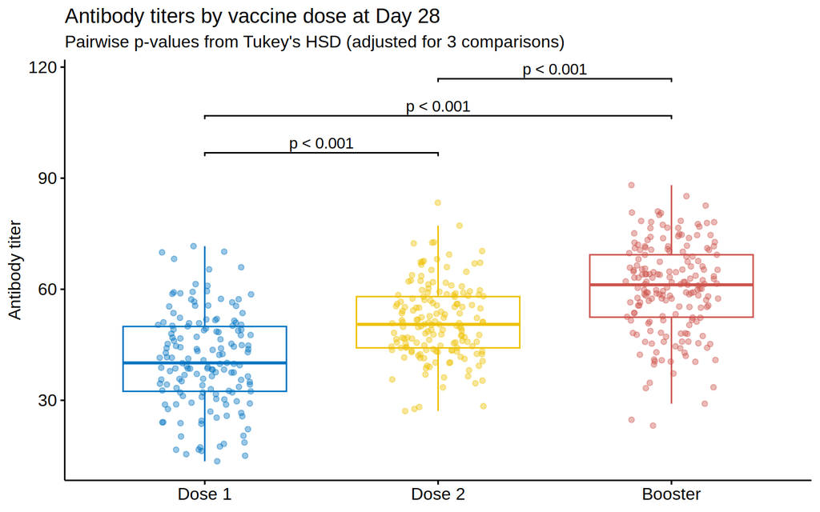

```r
tk <- as.data.frame(tukey$dose) %>% rownames_to_column("pair") %>%
  separate(pair, into = c("g2", "g1"), sep = "-") %>%
  mutate(label = ifelse(`p adj` < 0.001, "p < 0.001", sprintf("p = %.3f", `p adj`)))
ymax <- max(day28$titer)

ggboxplot(day28, x = "dose", y = "titer", color = "dose", palette = c("#0073C2", "#EFC000", "#CD534C"),
          add = "jitter", add.params = list(alpha = 0.4)) +
  geom_signif(comparisons = map2(tk$g1, tk$g2, c),
              annotations = tk$label,
              y_position = ymax + c(5, 15, 25), tip_length = 0.01) +
  labs(title = "Antibody titers by vaccine dose at Day 28",
       subtitle = "Pairwise p-values from Tukey's HSD (adjusted for 3 comparisons)",
       y = "Antibody titer", x = NULL) +
  theme(legend.position = "none")
```

### B. Mean titer over time vs. the simulated truth

Points and error bars are the observed group means with 95% confidence intervals; dashed lines are the expected values implied by the simulation code. (An earlier version fitted quadratic curves to the four group means and reported adjusted R² ≈ 1; three parameters fitted to four points will always fit almost perfectly, so that R² carried no information and has been removed.)

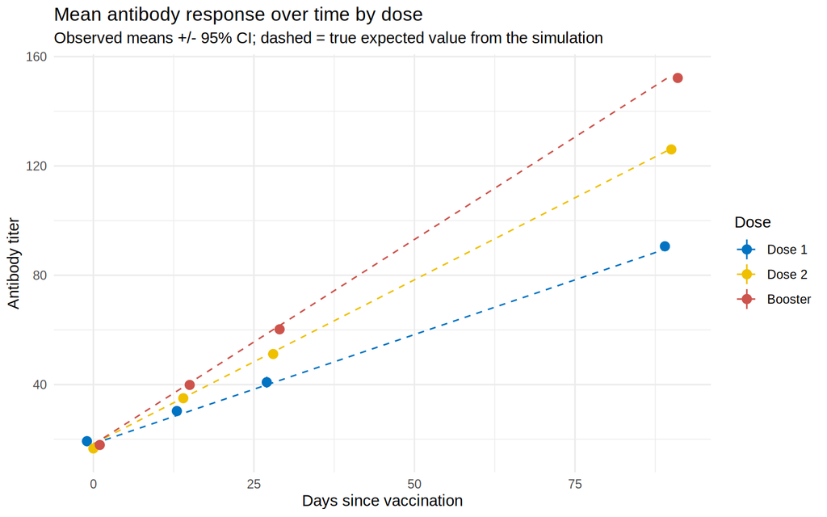

```r
comorb_share <- patients %>% group_by(dose) %>%
  summarise(p_comorb = mean(comorbidity != "None")) %>%
  mutate(dose = factor(dose, levels = levels(sim_data$dose)))

truth_lines <- expand_grid(dose = factor(names(true_slopes), levels = levels(sim_data$dose)),
                           time = seq(0, 90, by = 1)) %>%
  left_join(comorb_share, by = "dose") %>%
  mutate(expected = 20 + true_slopes[as.character(dose)] * time - 3.5 * p_comorb)

mean_titers <- sim_data %>%
  group_by(dose, time) %>%
  summarise(mean_titer = mean(titer), se = sd(titer) / sqrt(n()), .groups = "drop")

ggplot(mean_titers, aes(x = time, y = mean_titer, color = dose)) +
  geom_line(data = truth_lines, aes(y = expected), linetype = "dashed") +
  geom_pointrange(aes(ymin = mean_titer - 1.96 * se, ymax = mean_titer + 1.96 * se),
                  position = position_dodge(width = 3)) +
  scale_color_manual(values = c("#0073C2", "#EFC000", "#CD534C")) +
  labs(title = "Mean antibody response over time by dose",
       subtitle = "Observed means +/- 95% CI; dashed = true expected value from the simulation",
       x = "Days since vaccination", y = "Antibody titer", color = "Dose") +
  theme_minimal()
```

### C. Top 10% responders at Day 90

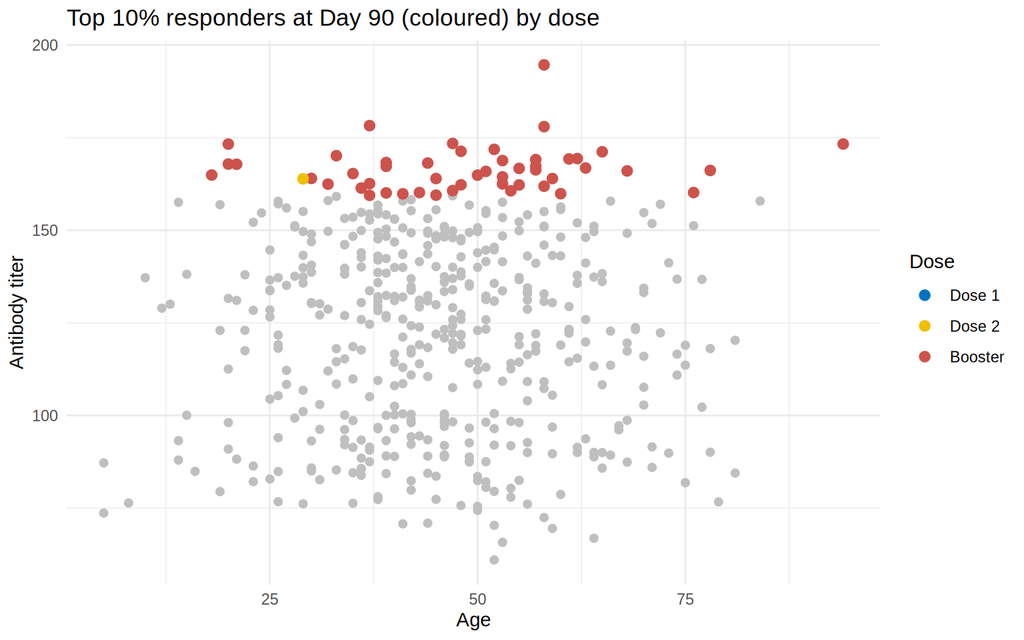

```r
day90 <- sim_data %>% filter(time == 90) %>%
  mutate(top10 = titer > quantile(titer, 0.9))

ggplot(day90, aes(x = age, y = titer)) +
  geom_point(data = filter(day90, !top10), color = "grey75", size = 1.8) +
  geom_point(data = filter(day90, top10), aes(color = dose), size = 2.4) +
  scale_color_manual(values = c("#0073C2", "#EFC000", "#CD534C"), drop = FALSE) +
  labs(title = "Top 10% responders at Day 90 (coloured) by dose",
       x = "Age", y = "Antibody titer", color = "Dose") +
  theme_minimal()
```

```r
day90 %>% filter(top10) %>% count(dose, name = "top10_count")
```

| dose | top10_count |
| --- | --- |
| Dose 2 | 1 |
| Booster | 49 |

Top responders are mostly booster recipients and spread across all ages. Both facts are built into the simulation (largest slope for the booster, no age effect), so the plot confirms the code rather than revealing biology.

## 6. Did the analysis recover the truth?

Because we know the data-generating values, we can check each estimate against them. The model below uses **all four timepoints**. Each patient contributes four rows, so it includes a random intercept per patient (`nlme::lme`) rather than treating the 2,000 rows as independent.

```r
mm_data <- sim_data %>% mutate(any_comorb = as.integer(comorbidity != "None"))

mixed <- lme(titer ~ time:dose + any_comorb + age + sex + bmi,
             random = ~ 1 | patient_id, data = mm_data, method = "REML")

est <- intervals(mixed, which = "fixed")$fixed %>% as.data.frame() %>%
  rownames_to_column("term")

truth <- tribble(
  ~term,                ~true_value,
  "(Intercept)",        20,
  "any_comorb",         -3.5,
  "age",                0,
  "sexMale",            0,
  "bmi",                0,
  "time:doseDose 1",    0.8,
  "time:doseDose 2",    1.2,
  "time:doseBooster",   1.5
)

recovery <- est %>% left_join(truth, by = "term") %>%
  transmute(term, true_value, estimate = est., lower, upper,
            covered = true_value >= lower & true_value <= upper) %>%
  mutate(across(c(estimate, lower, upper), ~ round(.x, 3)))
recovery
```

| term | true_value | estimate | lower | upper | covered |
| --- | --- | --- | --- | --- | --- |
| (Intercept) | 20.0 | 23.182 | 19.654 | 26.710 | TRUE |
| any_comorb | -3.5 | -4.192 | -5.175 | -3.209 | TRUE |
| age | 0.0 | 0.000 | -0.034 | 0.033 | TRUE |
| sexMale | 0.0 | 0.754 | -0.230 | 1.737 | TRUE |
| bmi | 0.0 | -0.126 | -0.247 | -0.005 | FALSE |
| time:doseDose 1 | 0.8 | 0.804 | 0.783 | 0.825 | TRUE |
| time:doseDose 2 | 1.2 | 1.193 | 1.172 | 1.213 | TRUE |
| time:doseBooster | 1.5 | 1.493 | 1.474 | 1.513 | TRUE |

Day-28 dose differences from the ANOVA, compared with the truth (difference in slope × 28):

```r
tibble(
  comparison = rownames(tukey$dose),
  true_diff = c(28 * (1.2 - 0.8), 28 * (1.5 - 0.8), 28 * (1.5 - 1.2)),
  estimate = tukey$dose[, "diff"],
  lower = tukey$dose[, "lwr"],
  upper = tukey$dose[, "upr"]
) %>%
  mutate(covered = true_diff >= lower & true_diff <= upper,
         across(c(estimate, lower, upper), ~ round(.x, 2)))
```

| comparison | true_diff | estimate | lower | upper | covered |
| --- | --- | --- | --- | --- | --- |
| Dose 2-Dose 1 | 11.2 | 10.33 | 7.24 | 13.41 | TRUE |
| Booster-Dose 1 | 19.6 | 19.36 | 16.35 | 22.37 | TRUE |
| Booster-Dose 2 | 8.4 | 9.04 | 6.08 | 11.99 | TRUE |

Variance components (truth: patient-level SD = 0, residual SD ≈ √(5² + 10²) ≈ 11.2):

```r
VarCorr(mixed)
```

```
## patient_id = pdLogChol(1)
##             Variance     StdDev
## (Intercept) 2.581034e-05  0.005080388
## Residual    1.243266e+02 11.150184525
```

**Takeaways**

- The dose slopes are recovered almost exactly, and the intercept and the comorbidity penalty have confidence intervals that cover their true values. Using all four timepoints pins the comorbidity penalty down more tightly than the single-timepoint logistic model.
- The BMI false positive from Section 4 persists here (its interval just excludes zero): BMI is fixed per patient, so the extra timepoints do not add independent information about it. Recovering seven of eight parameters with 95% intervals is in line with what 95% coverage means.
- The estimated patient-level SD is essentially zero because the simulation has no within-patient correlation. Real longitudinal titers are strongly correlated within a person; in that case pooling timepoints in an ordinary ANOVA/OLS would understate the standard errors, which is why the mixed model (or one-row-per-patient summaries) is the right default.
- A natural next step is to make the simulation more realistic (a patient random intercept, a peak followed by waning) and check that the same pipeline still recovers the truth.